# Projekt_EDA

```python
import json
import pandas as pd
import numpy as np
import matplotlib.pyplot as plt
import seaborn as sns
from matplotlib.ticker import PercentFormatter

sns.set_theme(style="whitegrid")

with open("Premiership_full_2324.json", "r", encoding="utf-8") as f:
    sezon2324 = json.load(f)

print("Matches loaded:", len(sezon2324))
```

```
Matches loaded: 380
```

The goal of my project was to analyze data from the top tier of English football - the Premier League. The data comes from the 2023/2024 season and contains details of all 380 matches played during that time.

```
1. Does the number of opponent's touches affect the number of cards received?
<class 'pandas.DataFrame'>
RangeIndex: 760 entries, 0 to 759
Data columns (total 2 columns):
 #   Column    Non-Null Count  Dtype
---  ------    --------------  -----
 0   kontakty  760 non-null    int64
 1   kartki    760 non-null    int64
dtypes: int64(2)
memory usage: 12.0 KB
None
```

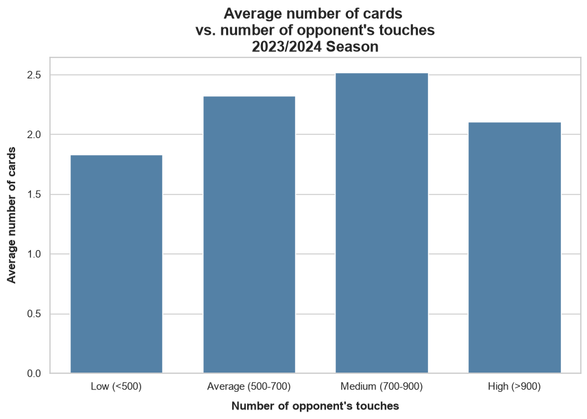

```python
print("1. Does the number of opponent's touches affect the number of cards received?")

kontakty_H, kontakty_A = [], []
kartki_H, kartki_A = [], []

for i in range(380):
    kontakty_H.append(sezon2324[i]['main_stats'][9]["H"])
    kontakty_A.append(sezon2324[i]['main_stats'][9]["A"])

for i in range(380):
    kartki_H.append(sezon2324[i]['main_stats'][7]["H"] + sezon2324[i]['main_stats'][8]["H"])
    kartki_A.append(sezon2324[i]['main_stats'][7]["A"] + sezon2324[i]['main_stats'][8]["A"])

Kontakty_kartki = pd.DataFrame({
    'kontakty': kontakty_A + kontakty_H,
    'kartki': kartki_H + kartki_A
})

print(Kontakty_kartki.info())

Kontakty_kartki['przedzialy'] = pd.cut(
    Kontakty_kartki['kontakty'],
    bins=[300, 500, 700, 900, 1200],
    labels=["Low (<500)", "Average (500-700)", "Medium (700-900)", "High (>900)"]
)

dane_do_wykresu1 = Kontakty_kartki.groupby('przedzialy', observed=False).agg(
    srednia_kartek=('kartki', 'mean'),
    liczba_meczow=('kartki', 'size')
).reset_index()

plt.figure(figsize=(10, 6))
sns.barplot(data=dane_do_wykresu1, x='przedzialy', y='srednia_kartek', color="#4682B4", width=0.7)
plt.title("Average number of cards \nvs. number of opponent's touches\n2023/2024 Season", fontweight="bold", fontsize=16)
plt.xlabel("Number of opponent's touches", fontweight="bold", fontsize=12, labelpad=10)
plt.ylabel("Average number of cards", fontweight="bold", fontsize=12, labelpad=10)
plt.show()
```

Thanks to the chart, we can observe interesting relationships between the number of opponent's touches and the number of cards received. In the first three groups ("Low", "Average", and "Medium"), we can see that the number of cards increases with the number of touches. We reach a peak in the group with touches between 700 and 900, where the average number of cards is 2.5 per match.

We can observe an interesting situation in the case of more than 900 touches. The average drops there to 2.1 cards per match, which is the 2nd lowest bar on our chart. This may indicate a change in tactics (in a situation where the opponent has complete control over the match) to "park the bus" and wait for counterattack opportunities.

```
2. Does a team that fouls more concede fewer goals?
<class 'pandas.DataFrame'>
RangeIndex: 760 entries, 0 to 759
Data columns (total 2 columns):
 #   Column  Non-Null Count  Dtype
---  ------  --------------  -----
 0   faule   760 non-null    int64
 1   gole    760 non-null    str
dtypes: int64(1), str(1)
memory usage: 12.0 KB
None
```

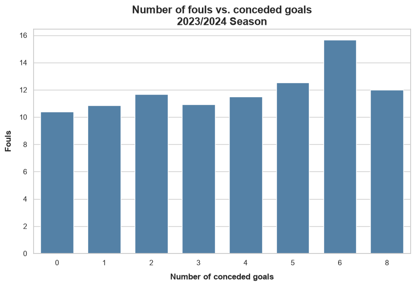

```python
print("2. Does a team that fouls more concede fewer goals?")

faule_H, faule_A = [], []
gole_H, gole_A = [], []

for i in range(380):
    faule_A.append(sezon2324[i]["team_stats"]["miscellaneous_away_team"][0]["Fls"])
    faule_H.append(sezon2324[i]["team_stats"]["miscellaneous_home_team"][0]["Fls"])
    gole_H.append(sezon2324[i]["team_stats"]["summary_home_team"][0]["Gls"])
    gole_A.append(sezon2324[i]["team_stats"]["summary_away_team"][0]["Gls"])

faule_gole = pd.DataFrame({
    'faule': pd.to_numeric(faule_A + faule_H),
    'gole': gole_H + gole_A
})

print(faule_gole.info())

dane_do_wykresu2 = faule_gole.groupby('gole').agg(
    srednia_fauli=('faule', 'mean'),
    liczba_przypadkow=('faule', 'size')
).reset_index()

plt.figure(figsize=(10, 6))
sns.barplot(data=dane_do_wykresu2, x='gole', y='srednia_fauli', color="#4682B4", width=0.7)
plt.title("Number of fouls vs. conceded goals\n2023/2024 Season", fontweight="bold", fontsize=16)
plt.xlabel("Number of conceded goals", fontweight="bold", fontsize=12, labelpad=10)
plt.ylabel("Fouls", fontweight="bold", fontsize=12, labelpad=10)
plt.show()
```

On the chart, we can observe that teams which conceded a lot of goals averaged more fouls. We can see this on the example of teams that did not concede any goals - an average of about 10 fouls per match (the lowest observable value), and teams that conceded 6 goals - an average of over 15 fouls per match (the highest observable value). This could be due to the growing frustration of players or a loss of control over the game, or simply an insufficiently large sample size - a team conceded as many as 6 goals in only 3 matches.

We can also observe that in the case of conceding 8 goals, the number of fouls drops significantly. However, just as in the case of matches where teams conceded 6 goals, it is difficult to draw interesting conclusions due to the sample size being too small.

```
3. Does playing at home provide an advantage in creating scoring opportunities?
```

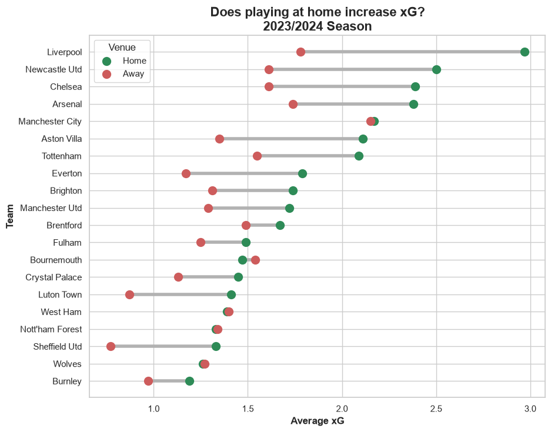

```python
print("3. Does playing at home provide an advantage in creating scoring opportunities?")

xG_H, xG_A = [], []
gospodarze, goscie = [], []

for i in range(380):
    xG_H.append(sezon2324[i]["main_stats"][13]["H"])
    xG_A.append(sezon2324[i]["main_stats"][13]["A"])
    gospodarze.append(sezon2324[i]["przebieg_meczu"][0]["HT"])
    goscie.append(sezon2324[i]["przebieg_meczu"][0]["AT"])

xG_df = pd.DataFrame({
    'xG_gospodarze': xG_H,
    'druzyna_gospodarzy': gospodarze,
    'xG_goscie': xG_A,
    'druzyna_gosci': goscie
})

dane_do_wykresu3_gospodarze = xG_df.groupby('druzyna_gospodarzy').agg(
    srednia_xG_H=('xG_gospodarze', lambda x: round(x.mean(), 2))
).reset_index().sort_values('druzyna_gospodarzy')

dane_do_wykresu3_goscie = xG_df.groupby('druzyna_gosci').agg(
    srednia_xG_A=('xG_goscie', lambda x: round(x.mean(), 2))
).reset_index().sort_values('druzyna_gosci')

dane_do_wykresu3 = pd.merge(dane_do_wykresu3_gospodarze, dane_do_wykresu3_goscie,
                            left_on='druzyna_gospodarzy', right_on='druzyna_gosci')
dane_do_wykresu3 = dane_do_wykresu3.rename(columns={'druzyna_gospodarzy': 'druzyna'})
dane_do_wykresu3['roznica'] = dane_do_wykresu3['srednia_xG_H'] - dane_do_wykresu3['srednia_xG_A']
dane_do_wykresu3 = dane_do_wykresu3.sort_values('srednia_xG_H', ascending=True)

plt.figure(figsize=(10, 8))
plt.hlines(y=dane_do_wykresu3['druzyna'], xmin=dane_do_wykresu3['srednia_xG_A'],
           xmax=dane_do_wykresu3['srednia_xG_H'], color='#b2b2b2', linewidth=4)
plt.scatter(dane_do_wykresu3['srednia_xG_H'], dane_do_wykresu3['druzyna'], color='#2E8B57', s=100, label='Home', zorder=3)
plt.scatter(dane_do_wykresu3['srednia_xG_A'], dane_do_wykresu3['druzyna'], color='#CD5C5C', s=100, label='Away', zorder=3)

plt.title("Does playing at home increase xG?\n2023/2024 Season", fontweight="bold", fontsize=16)
plt.xlabel("Average xG", fontweight="bold", fontsize=12)
plt.ylabel("Team", fontweight="bold", fontsize=12)
plt.legend(title="Venue")
plt.show()
```

As we can observe, the dumbbell chart confirms our hypothesis about the existence of an advantage in creating scoring opportunities on the home pitch. This phenomenon is visible for most teams - the xG was higher at home than away.

This is best seen on the example of Liverpool, which achieves an incredible xG at Anfield - close to 3, while on away games the indicator drops significantly. It is similar in the cases of teams such as Chelsea or Newcastle United.

However, we can also observe that there are teams like Manchester City, which have an xG indicator at a similar level regardless of where they play their match.

```
4. Which referee whistles for the most fouls?
```

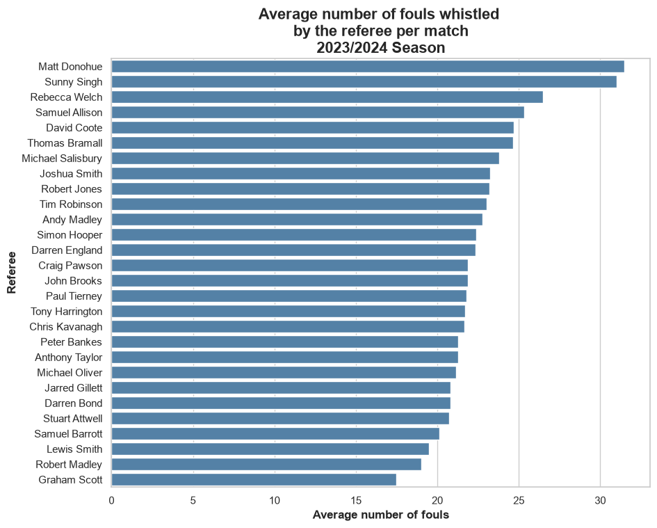

```python
print("4. Which referee whistles for the most fouls?")

sedzia = []

for i in range(380):
    sedzia.append(str(sezon2324[i]["inf_podstawowe"][0]["arbiter"]))

sedzia_faule = pd.DataFrame({
    'sedzia': sedzia,
    'faule': np.array(faule_A, dtype=float) + np.array(faule_H, dtype=float)
})

dane_do_wykresu5 = sedzia_faule.groupby('sedzia').agg(
    suma_faule=('faule', 'sum'),
    srednia=('faule', lambda x: round(x.mean(), 2)),
    liczba_meczy=('faule', 'size')
).reset_index().sort_values('srednia', ascending=False)

plt.figure(figsize=(10, 8))
sns.barplot(data=dane_do_wykresu5, x='srednia', y='sedzia', color="#4682B4")
plt.title("Average number of fouls whistled \nby the referee per match\n2023/2024 Season", fontweight="bold", fontsize=16)
plt.xlabel("Average number of fouls", fontweight="bold", fontsize=12)
plt.ylabel("Referee", fontweight="bold", fontsize=12)
plt.show()
```

An analysis of the referees' work in terms of the average number of fouls whistled shows differences in the level of acceptable aggression from teams. At the very top, we can see Matt Donohue and Sunny Singh, who exceed over 30 fouls per match.

At the other end of the chart is Graham Scott, who turned out to be the most lenient referee (about 18 fouls per match), which promotes game fluidity.

```python
print("5. Which team plays the most aggressively, and which the smartest?")

zolte_H, czerwone_H, zolte_A, czerwone_A = [], [], [], []

for i in range(380):
    zolte_H.append(sezon2324[i]['main_stats'][7]["H"])
    czerwone_H.append(sezon2324[i]['main_stats'][8]["H"])
    zolte_A.append(sezon2324[i]['main_stats'][7]["A"])
    czerwone_A.append(sezon2324[i]['main_stats'][8]["A"])

faule_kartki_H = pd.DataFrame({
    'gospodarze': gospodarze,
    'faule_H': np.array(faule_H, dtype=float),
    'zolte_H': zolte_H,
    'czerwone_H': czerwone_H
})

faule_kartki_A = pd.DataFrame({
    'goscie': goscie,
    'faule_A': np.array(faule_A, dtype=float),
    'zolte_A': zolte_A,
    'czerwone_A': czerwone_A
})

print(faule_kartki_H.info())

faule_kartki_H = faule_kartki_H.groupby('gospodarze').sum().reset_index()
faule_kartki_A = faule_kartki_A.groupby('goscie').sum().reset_index()

faule_kartki = pd.merge(faule_kartki_H, faule_kartki_A, left_on='gospodarze', right_on='goscie')
faule_kartki = faule_kartki.rename(columns={'gospodarze': 'druzyna'})
faule_kartki['faule'] = faule_kartki['faule_H'] + faule_kartki['faule_A']
faule_kartki['zolte'] = faule_kartki['zolte_H'] + faule_kartki['zolte_A']
faule_kartki['czerwone'] = faule_kartki['czerwone_H'] + faule_kartki['czerwone_A']
faule_kartki['indeks_agresji'] = faule_kartki['zolte'] + 2 * faule_kartki['czerwone']

faule_kartki['faule_na_kartke'] = ((faule_kartki['czerwone'] + faule_kartki['zolte']) / faule_kartki['faule']).apply(lambda x: f"{x:.2%}")

faule_kartki = faule_kartki[['druzyna', 'faule', 'zolte', 'czerwone', 'indeks_agresji', 'faule_na_kartke']].sort_values('indeks_agresji', ascending=False)
print(faule_kartki)
```

```
5. Which team plays the most aggressively, and which the smartest?
<class 'pandas.DataFrame'>
RangeIndex: 380 entries, 0 to 379
Data columns (total 4 columns):
 #   Column      Non-Null Count  Dtype
---  ------      --------------  -----
 0   gospodarze  380 non-null    str
 1   faule_H     380 non-null    float64
 2   zolte_H     380 non-null    int64
 3   czerwone_H  380 non-null    int64
dtypes: float64(1), int64(2), str(1)
memory usage: 12.0 KB
None
            druzyna  faule  zolte  czerwone  indeks_agresji faule_na_kartke
6           Chelsea  446.0    109         4             117          25.34%
```

[output cut: 19 more lines]

To investigate who plays the most aggressively, I created an aggression index, which shows which team played the most unfair football. First place goes to Chelsea, which accumulated 117 points and is characterized by a high number of "tackles" or unsportsmanlike conduct, because every 4th foul they commit ends with a penalty card for a player.

At the bottom are Manchester City and Arsenal, which confirms that higher ball possession is characterized by a lower number of fouls.

```python
print("6. Which team is most dependent on points earned at home?")

punkty_boisko = pd.DataFrame({
    'gospodarze': gospodarze,
    'gole_H': np.array(gole_H, dtype=float),
    'goscie': goscie,
    'gole_A': np.array(gole_A, dtype=float)
})

cond_H = [punkty_boisko['gole_H'] > punkty_boisko['gole_A'], punkty_boisko['gole_H'] == punkty_boisko['gole_A']]
punkty_boisko['punkty_H'] = np.select(cond_H, [3, 1], default=0)

cond_A = [punkty_boisko['gole_A'] > punkty_boisko['gole_H'], punkty_boisko['gole_H'] == punkty_boisko['gole_A']]
punkty_boisko['punkty_A'] = np.select(cond_A, [3, 1], default=0)

punkty_dom = punkty_boisko.groupby('gospodarze')['punkty_H'].sum().reset_index()
punkty_wyjazd = punkty_boisko.groupby('goscie')['punkty_A'].sum().reset_index()

punkty_zdobyte = pd.merge(punkty_dom, punkty_wyjazd, left_on='gospodarze', right_on='goscie')
punkty_zdobyte = punkty_zdobyte.rename(columns={'gospodarze': 'druzyna'}).drop('goscie', axis=1)

punkty_zdobyte['suma_punkty'] = punkty_zdobyte['punkty_H'] + punkty_zdobyte['punkty_A']
punkty_zdobyte['procent_H'] = punkty_zdobyte['punkty_H'] / punkty_zdobyte['suma_punkty']
punkty_zdobyte = punkty_zdobyte.sort_values('procent_H', ascending=False)

punkty_zdobyte_disp = punkty_zdobyte.copy()
punkty_zdobyte_disp['procent_H'] = punkty_zdobyte_disp['procent_H'].apply(lambda x: f"{x:.2%}")
print(punkty_zdobyte_disp)
print(punkty_zdobyte.describe())
```

```
6. Which team is most dependent on points earned at home?
            druzyna  punkty_H  punkty_A  suma_punkty procent_H
16    Sheffield Utd        12         5           17    70.59%
11       Luton Town        16         8           24    66.67%
14    Newcastle Utd        40        20           60    66.67%
4          Brighton        30        16           46    65.22%
18         West Ham        33        22           55    60.00%
1       Aston Villa        41        28           69    59.42%
9            Fulham        29        20           49    59.18%
10        Liverpool        46        33           79    58.23%
7    Crystal Palace        29        21           50    58.00%
6           Chelsea        37        28           65    56.92%
8           Everton        30        23           53    56.60%
17        Tottenham        36        29           65    55.38%
13   Manchester Utd        33        27           60    55.00%
19           Wolves        23        19           42    54.76%
2       Bournemouth        25        21           46    54.35%
15  Nott'ham Forest        20        17           37    54.05%
3         Brentford        20        17           37    54.05%
0           Arsenal        46        40           86    53.49%
12  Manchester City        46        45           91    50.55%
5           Burnley        13        13           26    50.00%
        punkty_H   punkty_A  suma_punkty  procent_H
count  20.000000  20.000000    20.000000  20.000000
mean   30.250000  22.600000    52.850000   0.579569
std    10.701082   9.692102    19.836901   0.055345
min    12.000000   5.000000    17.000000   0.500000
25%    22.250000  17.000000    40.750000   0.542744
50%    30.000000  21.000000    51.500000   0.567634
75%    37.750000  28.000000    65.000000   0.595652
max    46.000000  45.000000    91.000000   0.705882
```

Thanks to the descriptive statistics, we can observe that, on average, teams earned 8 more points at home than away, and for an average team, the home point tally accounted for up to 58% of all earned points.

This is best seen on the example of Sheffield United, which earned as much as 70.6% of its points on its home pitch.

However, there are also teams that do identically well away as at home (they earned the same amount of points). An example of such a team is Burnley, which earned 13 points both at home and away.

```
7. Do referees exhibit biases against specific teams?
       ilosc_meczy
count    23.000000
mean     26.739130
std      16.017653
min       2.000000
25%      14.000000
50%      24.000000
75%      39.500000
max      53.000000
```

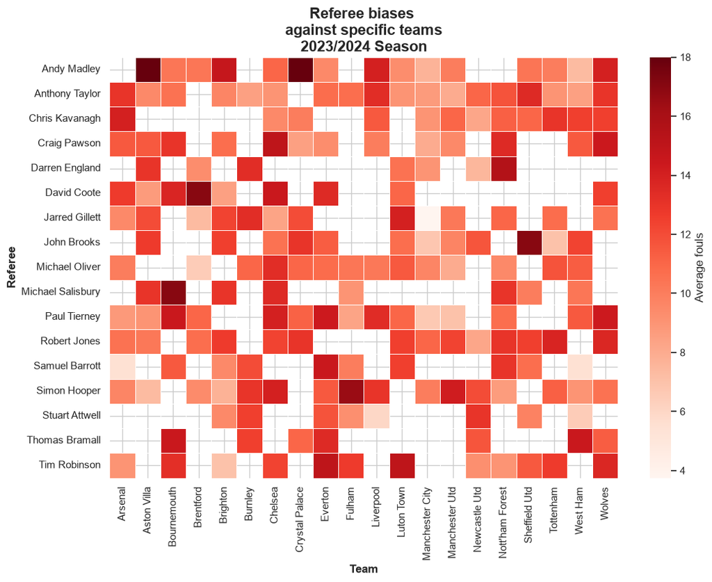

```python
print("7. Do referees exhibit biases against specific teams?")

druzyny_sedziowie_H = pd.DataFrame({'sedzia': sedzia, 'druzyna': gospodarze, 'faule': np.array(faule_H, dtype=float)})
druzyny_sedziowie_A = pd.DataFrame({'sedzia': sedzia, 'druzyna': goscie, 'faule': np.array(faule_A, dtype=float)})

druzyny_sedziowie = pd.concat([druzyny_sedziowie_A, druzyny_sedziowie_H])

druzyny_sedziowie = druzyny_sedziowie.groupby(['sedzia', 'druzyna']).agg(
    srednia=('faule', lambda x: round(x.mean(), 2)),
    liczba_spotkan=('faule', 'size')
).reset_index()

druzyny_sedziowie = druzyny_sedziowie[druzyny_sedziowie['liczba_spotkan'] >= 2]

sedziowie_sedziujacy = druzyny_sedziowie.groupby('sedzia').agg(ilosc_meczy=('liczba_spotkan', 'sum')).reset_index()
print(sedziowie_sedziujacy.describe())

sedziowie_sedziujacy = sedziowie_sedziujacy[sedziowie_sedziujacy['ilosc_meczy'] >= 14]

dane_do_wykresu8 = druzyny_sedziowie[druzyny_sedziowie['sedzia'].isin(sedziowie_sedziujacy['sedzia'])]

heatmap_data = dane_do_wykresu8.pivot(index='sedzia', columns='druzyna', values='srednia')

plt.figure(figsize=(12, 8))
sns.heatmap(heatmap_data, cmap="Reds", linewidths=.5, cbar_kws={'label': 'Average fouls'})
plt.title("Referee biases \nagainst specific teams\n2023/2024 Season", fontweight="bold", fontsize=16)
plt.xlabel("Team", fontweight="bold", fontsize=12)
plt.ylabel("Referee", fontweight="bold", fontsize=12)
plt.xticks(rotation=90)
plt.show()
```

For the analysis, I chose referees who officiated a minimum of 14 matches.

However, a vertical analysis also confirms the conclusions from the previous research problem regarding aggressive play or smartness. We can notice that Chelsea has most squares in darker colors, whereas light colors dominate for Manchester City.

```python
print("8. How many goals does a team need to score to earn a single point?")

punkty_bramki_H = punkty_boisko[['gospodarze', 'gole_H', 'punkty_H']].rename(columns={'gospodarze': 'druzyna', 'gole_H': 'gole', 'punkty_H': 'punkty'})
punkty_bramki_A = punkty_boisko[['goscie', 'gole_A', 'punkty_A']].rename(columns={'goscie': 'druzyna', 'gole_A': 'gole', 'punkty_A': 'punkty'})

punkty_bramki = pd.concat([punkty_bramki_A, punkty_bramki_H])

punkty_bramki = punkty_bramki.groupby('druzyna').sum().reset_index()
punkty_bramki['cena_1_punkta'] = punkty_bramki['gole'] / punkty_bramki['punkty']
punkty_bramki = punkty_bramki.sort_values('cena_1_punkta', ascending=False)

print(punkty_bramki.head())
print(punkty_bramki.tail())
print(punkty_bramki.describe())
```

```
8. How many goals does a team need to score to earn a single point?
          druzyna  gole  punkty  cena_1_punkta
11     Luton Town  49.0      24       2.041667
16  Sheffield Utd  31.0      17       1.823529
5         Burnley  40.0      26       1.538462
3       Brentford  54.0      37       1.459459
14  Newcastle Utd  83.0      60       1.383333
            druzyna  gole  punkty  cena_1_punkta
12  Manchester City  94.0      91       1.032967
10        Liverpool  80.0      79       1.012658
0           Arsenal  86.0      86       1.000000
13   Manchester Utd  57.0      60       0.950000
8           Everton  40.0      53       0.754717
            gole     punkty  cena_1_punkta
count  20.000000  20.000000      20.000000
mean   59.850000  52.850000       1.210419
std    17.104247  19.836901       0.307424
min    31.000000  17.000000       0.754717
25%    49.000000  40.750000       1.040850
50%    55.000000  51.500000       1.110544
75%    73.000000  65.000000       1.339077
max    94.000000  91.000000       2.041667
```

By calculating the "price of a single point", we can evaluate the value of one goal.

The team that had to score the most goals to earn a single point was Luton Town. They had to score about 2 goals in exchange for 1 point in the table.

The opposite of Luton is Everton, which had to score only 0.755 goals to earn a point. This means that every goal was incredibly important for Everton.

The average value of a point in the league is 1.21 goals, but the median is 1.11, suggesting that most of the league performed better than the average indicates, which is likely inflated by outliers.

```
9. What was the most frequent scoreline?
```

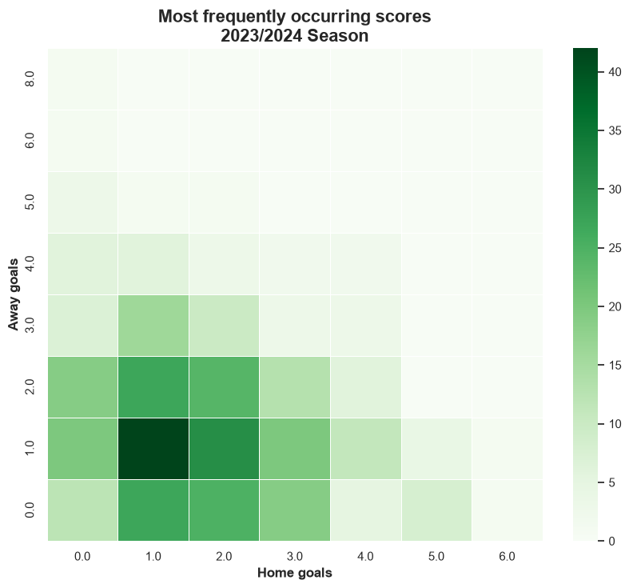

```python
print("9. What was the most frequent scoreline?")

dane_do_wykresu10 = punkty_boisko.groupby(['gole_H', 'gole_A']).size().reset_index(name='liczba_wystapien')

heatmap_wyniki = dane_do_wykresu10.pivot(index='gole_A', columns='gole_H', values='liczba_wystapien').fillna(0)

plt.figure(figsize=(10, 8))
sns.heatmap(heatmap_wyniki, cmap="Greens", linewidths=.5, annot=False)
plt.gca().invert_yaxis()
plt.title("Most frequently occurring scores\n2023/2024 Season", fontweight="bold", fontsize=16)
plt.xlabel("Home goals", fontweight="bold", fontsize=12)
plt.ylabel("Away goals", fontweight="bold", fontsize=12)
plt.show()
```

The heatmap leaves no doubt - the most frequent final scoreline for matches in the Premier League was 1:1. We can notice the darkest shade of green in this square.

The most darker colors occur with a low number of goals - one/two, i.e., scores like 1:2, 2:1, 2:0, etc.